# Tensorflow with Keras

Jameson Watts, Ph.D.

04/11/2020

## Agenda

1. Last group modeling assignment
2. Deep Learning using the Keras API
3. Breakout sessions
4. Review of deep learning concepts

**Worth reading:** https://www.fharrell.com/post/classification/

# Last Modeling Assignment

1. Predict whether a customer will be a repeat purchaser
2. Using any method you’d like
3. Evaluated using AUC

**Turn in:**

A clearly annotated RMD that takes the ecommerce dataset as input and outputs a set of class predictions that can be used to make an ROC curve and calculate AUC.

**Present:**

A maximum of 10 slides (powerpoint or html), without any code, that demonstrates

- how and why you created/selected the features used
- the choice and design of your model
- results and recommendations to management

**Rules:**

- Every group member must participate in the presentation*
- Date variable can only be used for seasonal indicators
- 50% of your grade for the assignment is based on presentation

## Setup

```r
knitr::opts_chunk$set(echo = TRUE, message = FALSE, warning = FALSE)
library(tidyverse)
library(lubridate)
```

## Load Data

```r
edata <- read_rds("../exams/ecommerce.rds")
glimpse(edata)
```

```
## Observations: 33,328
## Variables: 4
## $ repeat_customer <lgl> FALSE, FALSE, FALSE, FALSE, TRUE, FALSE, FALSE, …
## $ date            <date> 2017-01-12, 2019-11-04, 2019-07-13, 2018-08-14,…
## $ final_total     <dbl> 25.11, 10.00, 25.00, 25.00, 94.00, 25.16, 50.00,…
## $ product_details <chr> "Product Name: The Stubby Antenna for Ford", "Pr…
```

```r
table(edata$repeat_customer)
```

```
##
## FALSE  TRUE
## 30978  2350
```

## Engineer a couple of basic features

```r
medata <- edata %>%
  mutate(repeat_customer=as.integer(repeat_customer)) %>%
  mutate(total = log(final_total)) %>%
  mutate(mini=as.integer(str_detect(product_details,"MINI"))) %>%
  mutate(bmw=as.integer(str_detect(product_details,"BMW"))) %>%
  mutate(holiday = as.integer(month(date) >= 10)) %>%
  mutate(basket_size = str_count(product_details,"Product Name:")) %>%
  select(-product_details, -date, -final_total)

head(medata)
```

| repeat_customer | total | mini | bmw | holiday | basket_size |
| --- | --- | --- | --- | --- | --- |
| 0 | 3.223266 | 0 | 0 | 0 | 1 |
| 0 | 2.302585 | 0 | 0 | 1 | 1 |
| 0 | 3.218876 | 0 | 0 | 0 | 1 |
| 0 | 3.218876 | 0 | 0 | 0 | 1 |
| 1 | 4.543295 | 0 | 0 | 0 | 2 |
| 0 | 3.225255 | 0 | 0 | 0 | 1 |

## Run a basic Logistic Model

```r
library(caret)

## create training and test partitions
train_rows <- sample(1:nrow(medata), size = 0.8 * nrow(medata))
train <- medata[train_rows,]
test <-medata[-train_rows,]

fit <- train(repeat_customer ~ .,
             data = train,
             trControl = trainControl(method="repeatedcv", repeats = 5),
             method = "glm",
             family = "binomial")

summary(fit)
```

```
##
## Call:
## NULL
##
## Deviance Residuals:
##     Min       1Q   Median       3Q      Max
## -1.7123  -0.3764  -0.3396  -0.3394   2.6918
##
## Coefficients:
##             Estimate Std. Error z value Pr(>|z|)
## (Intercept) -3.66612    0.14025 -26.141  < 2e-16 ***
## total        0.16250    0.03946   4.118 3.82e-05 ***
## mini         0.69165    0.06176  11.199  < 2e-16 ***
## bmw         -0.59536    0.13625  -4.370 1.24e-05 ***
## holiday     -0.17543    0.06257  -2.804  0.00505 **
## basket_size  0.31801    0.04154   7.655 1.93e-14 ***
## ---
## Signif. codes:  0 '***' 0.001 '**' 0.01 '*' 0.05 '.' 0.1 ' ' 1
##
## (Dispersion parameter for binomial family taken to be 1)
##
##     Null deviance: 13627  on 26661  degrees of freedom
## Residual deviance: 13240  on 26656  degrees of freedom
## AIC: 13252
##
## Number of Fisher Scoring iterations: 5
```

```r
varImp(fit)
```

```
## glm variable importance
##
##             Overall
## mini         100.00
## basket_size   57.79
## bmw           18.65
## total         15.65
## holiday        0.00
```

## Interpretation

```r
odds <- exp(coef(fit$finalModel))
data.frame(name = names(odds), odds = odds) %>%
  mutate(probability=odds/(1+odds)) %>%
  arrange(desc(odds))
```

| name | odds | probability |
| --- | --- | --- |
| mini | 1.9970005 | 0.6663331 |
| basket_size | 1.3743859 | 0.5788385 |
| total | 1.1764443 | 0.5405350 |
| holiday | 0.8390950 | 0.4562543 |
| bmw | 0.5513635 | 0.3554057 |
| (Intercept) | 0.0255756 | 0.0249378 |

## Confusion Matrix

```r
prob <- predict(fit, newdata=test)
pred <- ifelse(prob > 0.5, 1, 0)

confusionMatrix(factor(pred),factor(test$repeat_customer))
```

```
## Confusion Matrix and Statistics
##
##           Reference
## Prediction    0    1
##          0 6202  463
##          1    0    1
##
##                Accuracy : 0.9305
##                  95% CI : (0.9242, 0.9365)
##     No Information Rate : 0.9304
##     P-Value [Acc > NIR] : 0.4932
##
##                   Kappa : 0.004
##
##  Mcnemar's Test P-Value : <2e-16
##
##             Sensitivity : 1.000000
##             Specificity : 0.002155
##          Pos Pred Value : 0.930533
##          Neg Pred Value : 1.000000
##              Prevalence : 0.930393
##          Detection Rate : 0.930393
##    Detection Prevalence : 0.999850
##       Balanced Accuracy : 0.501078
##
##        'Positive' Class : 0
##
```

## Ouch. Maybe add some weights?

```r
weights <- train %>%
  mutate(weight=if_else(repeat_customer==1,13,1))

fit <- train(as.integer(repeat_customer) ~ .,
             data = train,
             trControl = trainControl(method="repeatedcv", repeats = 5),
             weights = weights$weight,
             method = "glm",
             family = "binomial")

prob <- predict(fit, newdata=test)
pred <- ifelse(prob > 0.5, 1, 0)

confusionMatrix(factor(pred),factor(test$repeat_customer))
```

```
## Confusion Matrix and Statistics
##
##           Reference
## Prediction    0    1
##          0 5025  308
##          1 1177  156
##
##                Accuracy : 0.7772
##                  95% CI : (0.767, 0.7872)
##     No Information Rate : 0.9304
##     P-Value [Acc > NIR] : 1
##
##                   Kappa : 0.0785
##
##  Mcnemar's Test P-Value : <2e-16
##
##             Sensitivity : 0.8102
##             Specificity : 0.3362
##          Pos Pred Value : 0.9422
##          Neg Pred Value : 0.1170
##              Prevalence : 0.9304
##          Detection Rate : 0.7538
##    Detection Prevalence : 0.8000
##       Balanced Accuracy : 0.5732
##
##        'Positive' Class : 0
##
```

## ROC Curve evaluation

Remember:

$Sensitivity = \frac{truePos}{allPos} = TruePosRate$

$Specificity = \frac{trueNeg}{allNeg} = TrueNegRate = 1 - FalsePosRate$

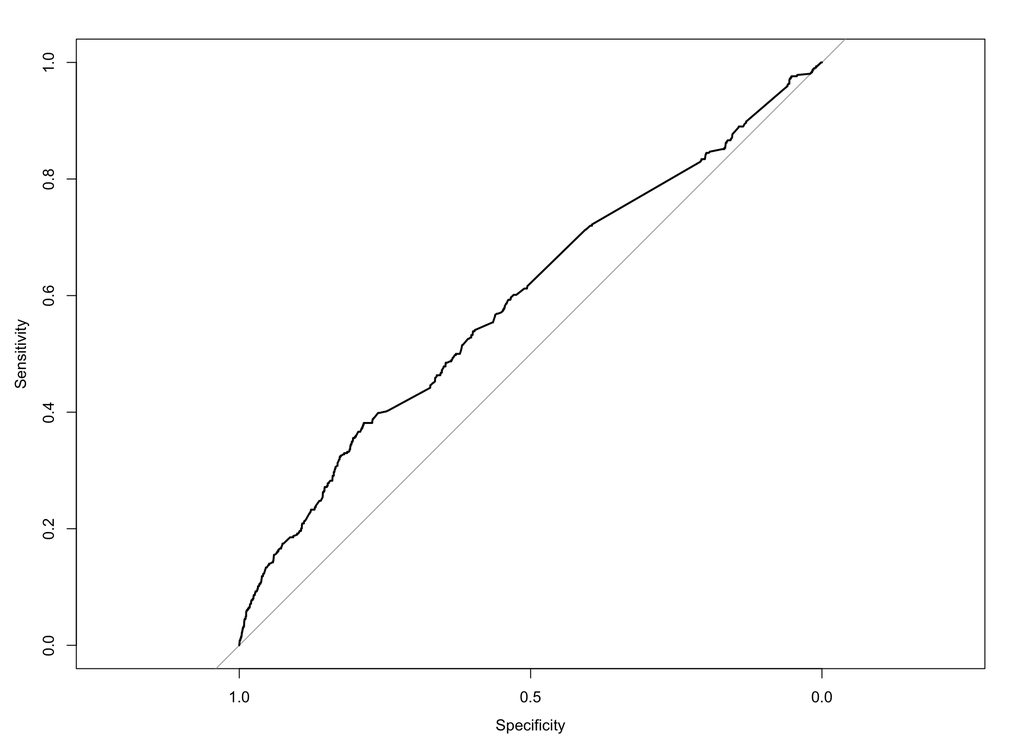

```r
library(pROC)
myRoc <- roc(test$repeat_customer, prob)
plot(myRoc)
```

```r
auc(myRoc)
```

```
## Area under the curve: 0.5917
```

## Tensor Flow?

```r
library(reticulate)
library(tensorflow)
library(keras)
```

## Check tensorflow setup

```r
tf_config()
```

```
## TensorFlow v1.15.0 (~/.virtualenvs/r-reticulate/lib/python3.7/site-packages/tensorflow)
## Python v3.7 (~/.virtualenvs/r-reticulate/bin/python)
```

## Create model

```r
x_train = as.matrix(select(train, -repeat_customer))
y_train = to_categorical(train$repeat_customer, num_classes = 2)


model = keras_model_sequential() %>%
  layer_dense(units = 32, activation = "relu", input_shape = ncol(x_train)) %>%
  layer_dense(units = ncol(y_train), activation = "softmax")

model %>%
  compile(
    optimizer = 'rmsprop',
    loss = 'mse',
    metrics = c('accuracy', 'mae')
  )

summary(model)
```

```
## Model: "sequential"
## ___________________________________________________________________________
## Layer (type)                     Output Shape                  Param #
## ===========================================================================
## dense (Dense)                    (None, 32)                    192
## ___________________________________________________________________________
## dense_1 (Dense)                  (None, 2)                     66
## ===========================================================================
## Total params: 258
## Trainable params: 258
## Non-trainable params: 0
## ___________________________________________________________________________
```

## Fit the model

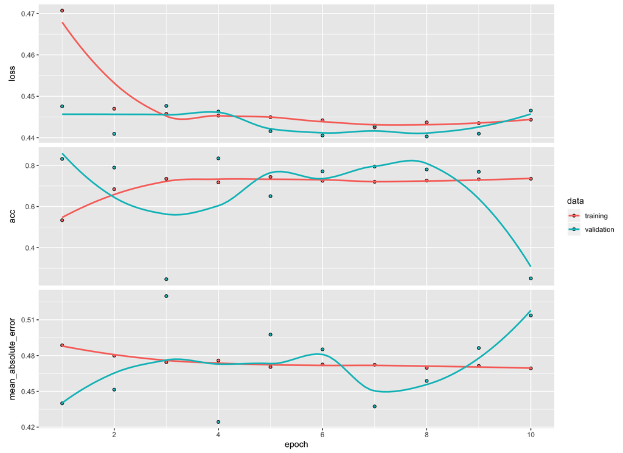

```r
history <- model %>%
  fit (
    x = x_train,
    y = y_train,
    epochs = 10,
    batch_size = 32,
    validation_split = .2,
    class_weight = list("0"=1,"1"=13)
)

plot(history)
```

## How well do we perform?

```r
x_test = as.matrix(select(test, -repeat_customer))

pred=predict_classes(model, x_test)
confusionMatrix(factor(pred),factor(test$repeat_customer))
```

```
## Confusion Matrix and Statistics
##
##           Reference
## Prediction    0    1
##          0 1295   77
##          1 4907  387
##
##                Accuracy : 0.2523
##                  95% CI : (0.2419, 0.2629)
##     No Information Rate : 0.9304
##     P-Value [Acc > NIR] : 1
##
##                   Kappa : 0.0074
##
##  Mcnemar's Test P-Value : <2e-16
##
##             Sensitivity : 0.2088
##             Specificity : 0.8341
##          Pos Pred Value : 0.9439
##          Neg Pred Value : 0.0731
##              Prevalence : 0.9304
##          Detection Rate : 0.1943
##    Detection Prevalence : 0.2058
##       Balanced Accuracy : 0.5214
##
##        'Positive' Class : 0
##
```

# Deep Learning Concepts

- Nodes
- Weights
- Activation Function (relu vs. softmax)
- Back propogation
- Epoch
- Batch Size
- Regularization (L2 vs. dropout)
- Hyperparameters

# References

https://tensorflow.rstudio.com/ https://towardsdatascience.com/how-to-create-a-sequential-model-in-keras-for-r